# Markesan District Chromebooks

By: Victoria Bengry

2023-09-13

## Introduction

> The dataset for this project was collected between the years of 2020 and 2023 during the summer inventory process for Chromebooks at Markesan District Schools. The data includes the variable of damage level which was assessed for each Chromebook that was used and collected each year. Many factors can impact the damage level of each Chromebook but in this analysis, there is a focus on the school year and age of Chromebook.

## Background

> The data involved in this project was collected by myself through my multiple years of work with Markesan District Schools. The original intention of this data was to keep current records of the high school Chromebooks in circulation throughout the school year. This data has now gained a greater purpose, as of now the district is looking at students being assigned the same Chromebook throughout their high school career. This way, in the end, the user can keep their device as a commendment of their graduation and the district can eliminate unnecessary technology waste. Chromebooks are not as easily managed when they can no longer update which inevitably happens to Chromebooks as they age, which leads to e-waste. Another potential benefit of this system could be less damaged Chromebooks. If students had a sense of responsibility for their own Chromebook they would ideally want to keep it in good condition.

> The original data frame for this project contained 928 entries and 5 variables. Each of the variables was kept for analysis and the number of data entries was paired down to 697 when entries with missing data were removed. Entries with missing values were removed to eliminate the risk of involving intermixed data of middle school Chromebooks with high school ones. The five variables included in the data are Chromebook name, damage level, grade level, sex, and school year.

## Analysis

> First, I took a look at the total number of Chromebooks collected and put into inventory for each year.

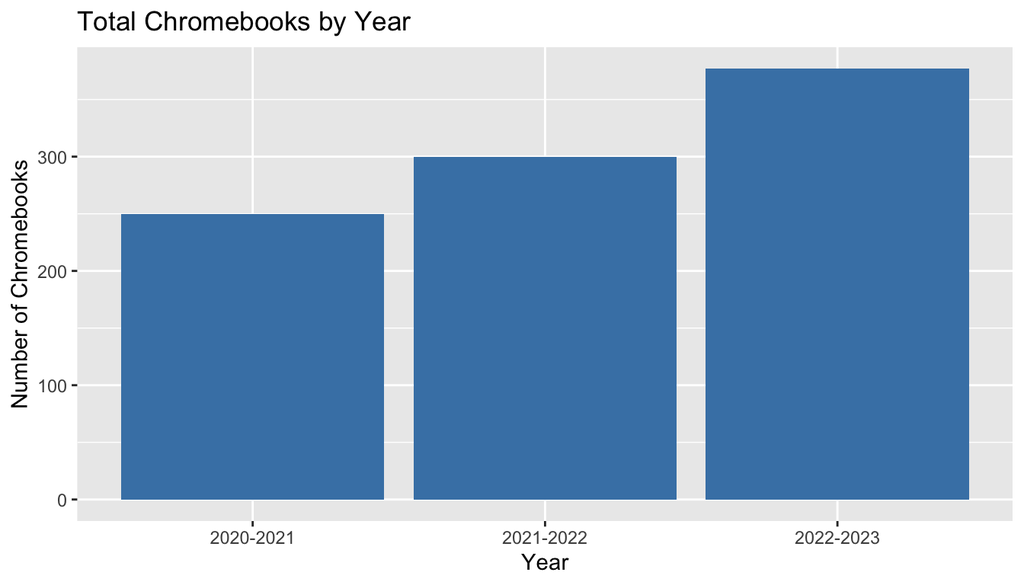

The number of Chromebooks collected after each school year increases over time which is due to the supply of district chromebooks and possibly more middle school chromebooks being accounted for.

> Here I looked at the total Chromebooks collected with the full information identified.

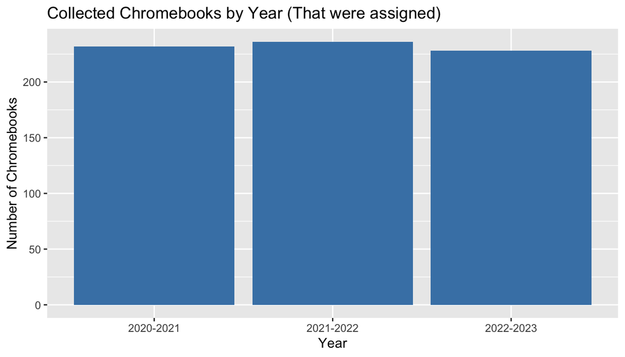

The total number of Chromebooks collected with full information is about the same throughout the years. Small changes can be accounted for by changing class sizes.

> Next, I explored the damage level of each Chromebook across all school years.

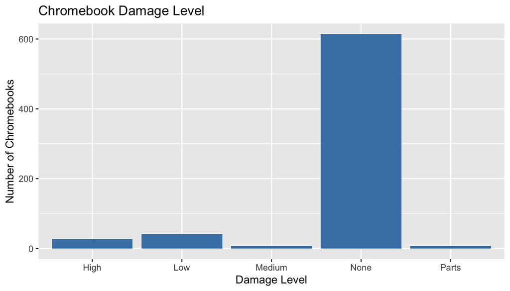

The damage level of Chromebooks throughout the three school years is for the most part “None”.

> Comparisons between the school years revealed more about the damage levels over time.

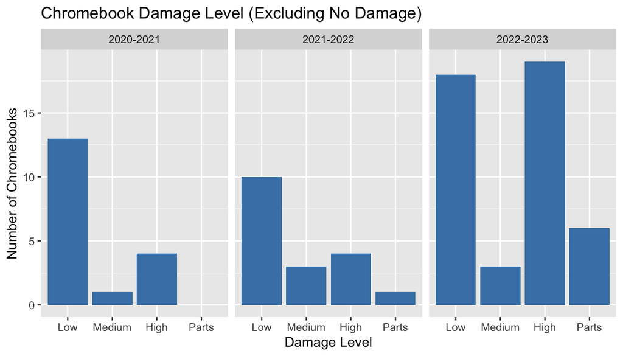

> Finally, based on the increasing damage levels across the school years, I evaluated the overall age of the Chromebooks that were given to students.

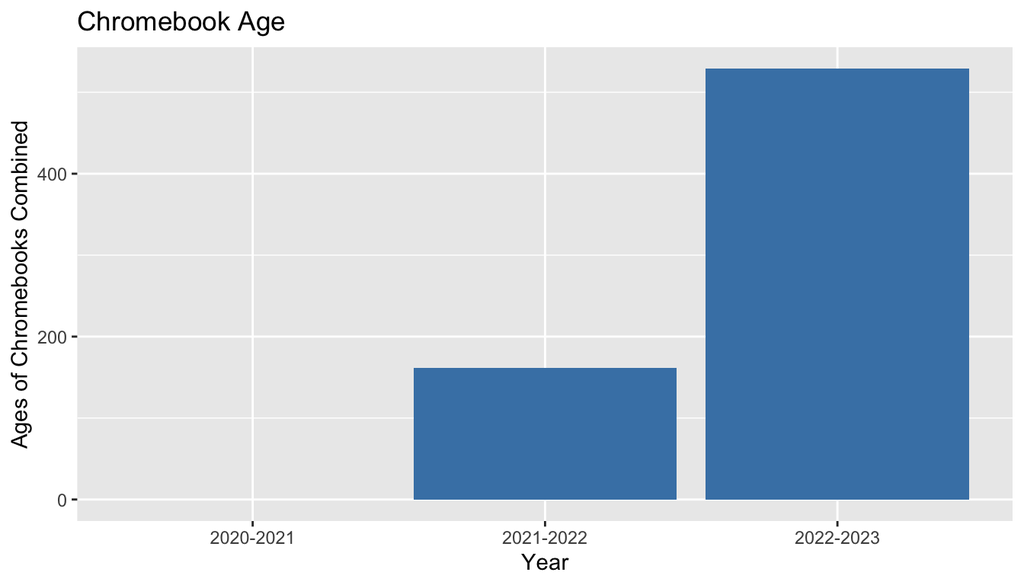

The overall age of the devices can potentially lead to problems as updates become less available.